# Intervalos de Confianza

## Intervalos de confianza en R

Veamos como calcular rápidamente los intervalos de confianza en R. Los intervalos de confianza para

se pueden calcular con la función **z.test** del paquete *TeachingDemos*

```r
library(TeachingDemos)
z.test(impedancia, sd=1.4)
```

```
##
##  One Sample z-test
##
## data:  impedancia
## z = 9.6901, n = 10.00000, Std. Dev. = 1.40000, Std. Dev. of the sample
## mean = 0.44272, p-value < 2.2e-16
## alternative hypothesis: true mean is not equal to 0
## 95 percent confidence interval:
##  3.422287 5.157713
## sample estimates:
## mean of impedancia
##               4.29
```

Con el interés exclusivo de determinar el intervalo de confianza, leemos los últimos dos resultados, en donde se reporta en intervalo $(l,u)$ con su nivel de confianza $\alpha=0.95$, junto con la media $\bar{x}$ para las observaciones en el vector *impedancia*.

## Intervalos de confianza cuando $\sigma_X$ es desconocido

El caso más común es que no sepamos ni la media $E(X)=\mu$ ni la varianza $V(X)=\sigma^2_X$ de las mediciones, al fin y al cabo son paramétros de la distribución de $X$ que siempre debemos estimar en algún momento.

Recordemos que queremos calcular $f_{inf}$ y $f_{sup}$ de

$$P( \frac{f_{inf}}{\sigma_{X}/\sqrt{n}} \leq \frac{\bar{X}-\mu}{\sigma_{X}/\sqrt{n}} \leq \frac{f_{sup}}{\sigma_{X}/\sqrt{n}} )=0.95.$$

Para este caso más general asumimos:

1. Que $X$ se distribuye normamente según $N(\mu, \sigma_X^2)$.
2. Que podemos sustituir $\sigma_x$ por su estimador $s=\frac{1}{n-1} \Sigma_i(x_i -\bar{x})^2$, calculado de los datos.

Si 1 y 2 se cumplen **entonces** se puede demostar que la variable $T=\frac{\bar{X}-\mu}{s/\sqrt{n}}$ es una variable aleatoria que sigue una distibucion t-student con n-1 grados de libertad $t(n-1)$.

$$P( \frac{f_{inf}}{s/\sqrt{n}} \leq \frac{\bar{X}-\mu}{s/\sqrt{n}} \leq \frac{f_{sup}}{s/\sqrt{n}} )=0.95$$

$$P( t_{0.025,n-1} \leq T \leq t_{0.975,n-1} )=0.95$$
siendo $T$ una variable aleatoria con una dostribución student-$t$ con n-1 grados de libertad, podemos calcular sus cuantiles al 2.5% y 97.5% usando la función **qt** (la función inversa de la acumulación de probabilidad para la distribución $t$ con $df$ grados de libertad)

```r
t0.025 <- qt(0.025,df=9)
t0.025
```

```
## [1] -2.262157
```

```r
t0.975 <- qt(0.975,df=9)
t0.975
```

```
## [1] 2.262157
```

Por lo tanto
$$f_{sup}=t_{0.975,n-1} \frac{s}{\sqrt{n}}=-f_{inf}$$
Para nuestro experimento de altavoces tenemos

```r
barx <- mean(impedancia)
barx
```

```
## [1] 4.29
```

```r
s <-sd(impedancia)
s
```

```
## [1] 1.903476
```

y por lo tanto el intervalo de confianza al 95% es

```r
fsup <- 2.262157*s/sqrt(10)
fsup
```

```
## [1] 1.361665
```

```r
CI <- c(barx-fsup,barx+fsup)
CI
```

```
## [1] 2.928335 5.651665
```

Este intervalo se calcula con la función **t.test** de R

```r
 t.test(impedancia, conf.level = 0.95)
```

```
##
##  One Sample t-test
##
## data:  impedancia
## t = 7.1271, df = 9, p-value = 5.502e-05
## alternative hypothesis: true mean is not equal to 0
## 95 percent confidence interval:
##  2.928335 5.651665
## sample estimates:
## mean of x
##      4.29
```

Donde vemos claramente el intervalo de confianza y el valor para $\bar{x}$. Notemos una propiedad imporatante para los dos tipos de intervalos de confianza que hemos calculado hasta aquí. En ambos casos la estandarización de $\bar{X}$ nos lleva a las variables aleatorias $Z$ y $T$ cuyas distribuciones no dependen de los parámetros $\mu$ y $\sigma$ de la distribución de $X$. Esto nos permite usar estas variables repetidas veces como **pivotes estadísticos** para calcular $f_{inf}$ y $f_{sup}$ en muchos de los casos que podemos asumir las condiciones 1. 2. de cada caso.

Por último, si necesitamos decidir si los experimentos ofrecen evidencia suficiente de que el proceso de producción de altavoces es consistente a un proceso de $4\Omega$, o sea si podemos asumir de que es razonablemente que $\mu = 4\Omega$ entonces debemos hacer una prueba de hipótesis. Esta prueba, en términos del intervalo de confianza, nos dice que *no podemos rechazar* la hipótesis de que $4\Omega$ sea $\mu$ debido a que $4\Omega$ esta **dentro** del intervalo $(2.928335, 5.651665)$ a 95% de confianza. Así pues, los datos nos permiten etiquetar los altavoces a $4\Omega$ de acuerdo con su promedio, pero la variabilidad de su producción también debe ser evaluada para saber sí esta es acceptable.

## Intervalos de confianza para $\sigma_X^2$

Veamos el intervalo de confianza para la varianza. Así como estimamos el parámetro $\mu$ para hubicar en dónde se encuentra el centro de gravadad de la distribución de $X$, también estimamos su varianza $\sigma^2_X$ para determinar su anchura. De hecho, hemos ultizado el valor $s$ para estimar $\sigma_X$ en el cálculo de los intervalos de confianza cuando $\sigma_X$ es desconocido.

Recordemos que $s^2$

```r
s<-sd(impedancia)
s^2
```

```
## [1] 3.623222
```

es un valor de la variable aleatoria
$$S^2= \frac{1}{n-1}\sum_i (X_i-\mu)^2$$
que estima $\sigma^2_X$ insesgadamente porque $E(S^2)=\sigma^2_X$.

Si $X$ se distribye normalmente $N(\mu, \sigma_X)$ entonces se pude encontar una variable **pivote** $S^2(n-1)/\sigma^2$ que se distribuye como una $\chi^2$ con n-1 grados de libertad,
$$\frac{S^2}{\sigma_X^2}(n-1)\rightarrow \chi^2_{n-1}$$
sin depender de $\sigma_X$. Para identificar el intervalo de confianza, buscamos $f_{inf}$ y $f_{sup}$ tal que
$$P(f_{inf}\leq \frac{S^2}{\sigma_X^2}(n-1) \leq f_{sup})=0.95$$
definidos por los cuantiles al 2.5% y 97.5% de esta variable aleatoria

$$P(\chi^2_{0.025,n-1} \leq \frac{S^2}{\sigma_X^2}(n-1) \leq \chi^2_{0.975,n-1})=0.95$$

```r
chi0.025 <- qchisq(0.025, df=9)
chi0.025
```

```
## [1] 2.700389
```

```r
chi0.975 <- qchisq(0.975, df=9)
chi0.975
```

```
## [1] 19.02277
```

Al resolver la desigualdad para $\sigma^2_x$

$$P(\frac{S^2 (n-1)}{\chi^2_{0.975,n-1}}\leq \sigma_X^2 \leq \frac{S^2(n-1)}{\chi^2_{0.025,n-1}})=0.95$$

la escribimos en términos del intervalo aleaorio $(L,U)$ con proabilidad contener a $\sigma_X^2$ el 95% de las veces, de acuerdo con $P(L\leq\sigma_X^2\leq U)=0.95$. Por lo tanto tenemos

$$L=\frac{S^2 (n-1)}{\chi^2_{0.975,n-1}}; U=\frac{S^2(n-1)}{\chi^2_{0.025,n-1}}$$

Para nuestros datos tenemos un valor concreto de este intervalo dado por el intervalo de confianza al 95%

```r
n <- 10
CI<-c(s^2*(n-1)/chi0.975, s^2*(n-1)/chi0.025)
CI
```

```
## [1]  1.714209 12.075665
```

Este se calcula en R con la función **sigma.test**

```r
sigma.test(impedancia)
```

```
##
##  One sample Chi-squared test for variance
##
## data:  impedancia
## X-squared = 32.609, df = 9, p-value = 0.0003124
## alternative hypothesis: true variance is not equal to 1
## 95 percent confidence interval:
##   1.714209 12.075665
## sample estimates:
## var of impedancia
##          3.623222
```

Así para la medición de nuestros 10 prototipos (histograma) tenemos que el intervalo de confianza para la varianza define dos distribuciones límite (roja y azul) que atrapan con una confianza de 95% la distribución de $X$ con varianza $\sigma_X$.

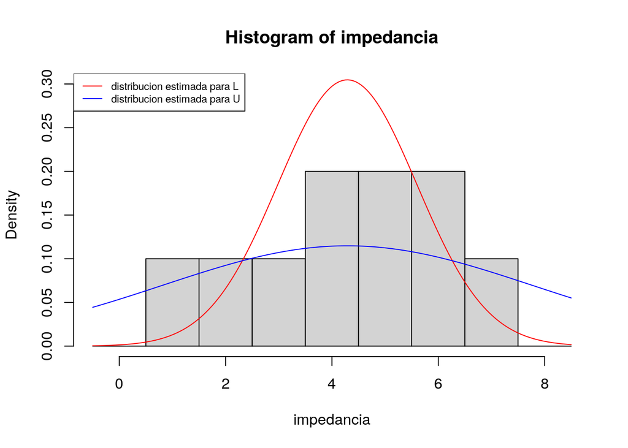

```r
x <- seq(-0.5,8.5,0.05)

hist(impedancia, br=seq(-0.5,8.5), freq=FALSE, col="lightgrey", ylim=c(0, 0.3))

lines(x,dnorm(x, mean=barx, sd=sqrt(CI[1])), col="red")
lines(x,dnorm(x, mean=barx, sd=sqrt(CI[2])),col="blue")

legend("topleft",c("distribucion estimada para L", "distribucion estimada para U"), col=c("red","blue"), lty=1, cex=0.7 )
```

Toda nuestra discusión se ha basado en intervalos de confianza al 95% pero claramente la confianza se puede aumentar al 99% definiendo

$$P(f_{inf} \leq \bar{X} - \mu \leq f_{sup} )=0.99$$
y los cuantiles de los pivotes al 0.005% y el 0.995%. En las funciones de R simplemente se ajusta el parámetro **conf.level = 0.99**.